# Material complementario · Taller 7

- Mostrar todo el código
- Ocultar todo el código
- Ver el código fuente

Más allá del núcleo del PCA · Multivariados II · Semana 3 · 2026-II

Autor/a

Javier Rodríguez-Barrios

Fecha de publicación

20 de octubre de 2026

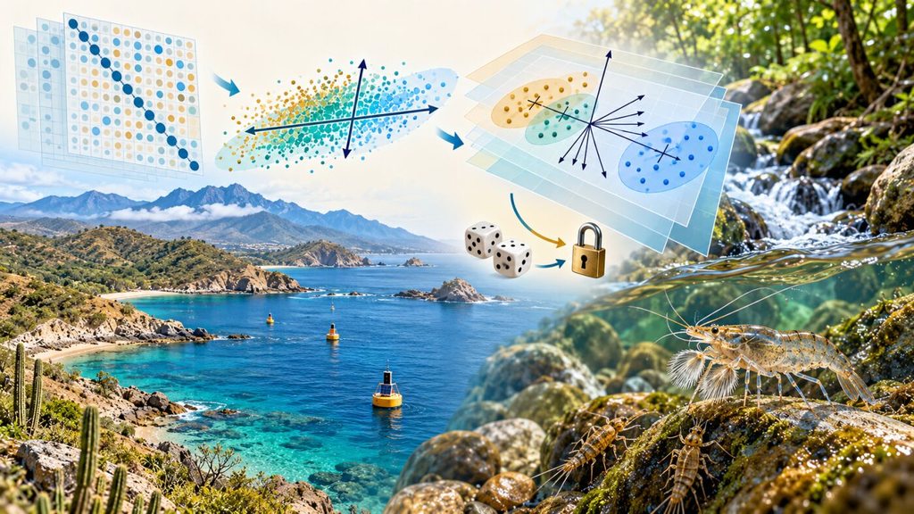

## Cómo usar este material

Este documento amplía el [Taller 7 · Análisis de componentes principales](https://javier-2712.github.io/Manuales/8.Manual_diseno_msc/html/Taller7_PCA.html). No es necesario recorrerlo completo: cada sección es independiente y responde a una situación que puede aparecer al preparar el estudio de caso o el propio proyecto de grado.

| Situación | Sección |
| --- | --- |
| Se quiere entender de dónde salen los autovalores, las cargas y las coordenadas que entrega `prcomp()` | 1. El álgebra del PCA |
| Se tiene una tabla pequeña de sitios con variables fisicoquímicas (tantas variables como sitios) | 2. PCA de bahías del Caribe |
| Se quiere ordenar una matriz de especies con un PCA, sin que dominen los taxones más abundantes | 3. PCA de Hellinger: macroinvertebrados del PNN Tayrona |
| Se necesita un biplot con control total de colores, flechas, elipses y rótulos | 4. Biplot construido con ggplot2 |
| Las muestras no son intercambiables (visitas, pares, bloques) y se quiere un p honesto en `envfit()` | 5. envfit con permutaciones restringidas |
| Se quiere que las figuras y tablas del PCA queden guardadas en archivos al renderizar | 6. Guardado automático |
| Se quiere practicar antes del estudio de caso | 7. Ejercicios de práctica |

**Código**

```r
# Librerías requeridas
library(tidyverse)
library(readxl)
library(kableExtra)
library(corrplot)
library(vegan)
library(factoextra)
library(ggrepel)     # Rótulos sin superposición (sección 4)
library(writexl)     # Guardar tablas en Excel (sección 6)

# Paletas del módulo
col_trib  <- c(T1 = "#2C6FB7", T2 = "#E3A33B", T3 = "#3E9C8F")
col_grp   <- c(`1` = "#2C6FB7", `2` = "#E3A33B")
col_epoca <- c(Lluvia = "#2C6FB7", Seca = "#E3A33B")

# Números con dos decimales fijos para el texto (−0.60 y no −0.6)
f1 <- function(x) formatC(x, format = "f", digits = 1)
f2 <- function(x) formatC(x, format = "f", digits = 2)
f3 <- function(x) formatC(x, format = "f", digits = 3)

# Ubicar un archivo de datos: en la carpeta del .qmd o en la raíz del proyecto
ruta_datos <- function(archivo) {
  rutas <- c(archivo, file.path("..", archivo), file.path("..", "..", archivo))
  ruta  <- rutas[file.exists(rutas)][1]
  if (is.na(ruta)) stop("No se encontró ", archivo,
                        ": cópielo en la carpeta de este .qmd o en la raíz del proyecto.")
  ruta
}
```

**Código**

```r
# Microalgas: matrices F, X y Y y PCA de correlación, igual que en el Taller 7
alg <- read_excel(ruta_datos("Microalgas.xlsx"), sheet = "Microalgas") %>%
  rename(Fragilaria = Fragillaria, Nitzschia  = Nitzchia,
         Surirella  = Surilella,   Gyrosigma  = Girosigma,
         Achnanthes = Achnantes) %>%
  mutate(Tributario = factor(Tributario),
         Visita     = factor(as.integer(sub(".*\\.", "", Cod))))   # T1.3 → 3

F_alg <- alg %>% select(Cod, Tributario, Visita)
X_alg <- alg %>% select(Amonio:Temp)
Y_alg <- alg %>% select(Fragilaria:Pinnularia)

# log10(x + 1) a todo salvo el pH y PCA de correlación
X_log <- X_alg %>% mutate(across(-pH, ~ log10(.x + 1)))
pca   <- prcomp(X_log, scale. = TRUE)
```

## 1. El álgebra del PCA: lo que hace `prcomp()`

**Pregunta:** ¿De dónde salen los autovalores, las cargas y las coordenadas que el Taller 7 leyó con `prcomp()`?

En el taller, el PCA se usó como una caja que entrega cuatro productos. Esta sección abre la caja con las mismas diez variables ambientales de microalgas. Solo se necesitan tres ideas: la matriz de correlación, sus **autovalores** y sus **autovectores**.

### 1.1 Un par de variables: la fórmula cabe en una línea

Con dos variables estandarizadas, la matriz de correlación es

$$R = \begin{pmatrix} 1 & r \\ r & 1 \end{pmatrix},$$

y sus dos autovalores son siempre $\lambda_1 = 1 + r$ y $\lambda_2 = 1 - r$. Los autovectores son las dos diagonales del plano, $(1, 1)/\sqrt{2}$ y $(1, -1)/\sqrt{2}$, cualquiera que sea r.

**Código**

```r
# Correlación conductividad–caudal (log10) y autovalores del par
r_cc <- cor(X_log$Conductividad, X_log$Caudal)
R2   <- cor(X_log[, c("Conductividad", "Caudal")])
eig2 <- eigen(R2)

# Fórmula frente a eigen()
rbind(formula = c(1 + r_cc, 1 - r_cc), eigen = eig2$values) %>% round(3)
```

```
         [,1]  [,2]
formula 1.828 0.172
eigen   1.828 0.172
```

**Código**

```r
# Autovectores: las dos diagonales del plano (el signo puede cambiar)
round(eig2$vectors, 3)
```

```
      [,1]   [,2]
[1,] 0.707 -0.707
[2,] 0.707  0.707
```

Con r = 0.83, el CP1 recoge (1 + r) / 2 = 91.4 % de la varianza: es el 91 % de la diapositiva 6 de la presentación 07. Si r fuera 0, cada eje recogería el 50 % y el PCA no resumiría nada; si r fuera 1, el CP1 recogería el 100 %.

### 1.2 Diez variables: `eigen()` sobre la matriz de correlación

**Código**

```r
# Matriz de correlación de las diez variables transformadas
R <- cor(X_log)

# Descomposición en autovalores (values) y autovectores (vectors)
eig <- eigen(R)

# Autovalores de eigen() frente a los de prcomp()
rbind(eigen = eig$values, prcomp = pca$sdev^2) %>% round(3)
```

```
        [,1]  [,2]  [,3]  [,4]  [,5]  [,6]  [,7]  [,8]  [,9] [,10]
eigen  3.118 1.769 1.491 1.358 0.862 0.535 0.423 0.261 0.116 0.067
prcomp 3.118 1.769 1.491 1.358 0.862 0.535 0.423 0.261 0.116 0.067
```

**Código**

```r
# Suma de los autovalores = traza de R = número de variables
c(suma_autovalores = sum(eig$values), traza = sum(diag(R)))
```

```
suma_autovalores            traza
              10               10
```

Los autovalores coinciden con los del taller (λ₁ = 3.12). Suman 10 porque la diagonal de R está llena de unos: cada variable estandarizada aporta una unidad de varianza.

**Código**

```r
# Autovectores (cargas) de los dos primeros ejes: eigen() frente a prcomp()
V <- eig$vectors
rownames(V) <- names(X_log)

cbind(eigen = V[, 1:2], prcomp = pca$rotation[, 1:2]) %>% round(2)
```

```
                            PC1   PC2
Amonio         0.11 -0.51  0.11 -0.51
Nitrito        0.22 -0.48  0.22 -0.48
Nitrato        0.19 -0.51  0.19 -0.51
Oxigeno       -0.10  0.23 -0.10  0.23
pH             0.08  0.29  0.08  0.29
Conductividad  0.53  0.12  0.53  0.12
Caudal         0.49  0.16  0.49  0.16
Vel_Corriente  0.42  0.22  0.42  0.22
Luz           -0.38  0.02 -0.38  0.02
Temp           0.21  0.13  0.21  0.13
```

Las columnas pueden diferir en el **signo**: un autovector multiplicado por −1 sigue siendo un autovector. Por eso el Taller 7 insiste en que el signo de un eje es arbitrario.

### 1.3 Coordenadas: Z × V

Las coordenadas (*scores*) de las muestras son la matriz estandarizada multiplicada por la matriz de autovectores:

**Código**

```r
# Matriz estandarizada (n × p) y coordenadas (n × p)
Z <- scale(X_log)
S <- Z %*% V

# Primeras muestras: a mano frente a prcomp() (se iguala el signo de cada eje)
signo <- sign(diag(cor(S, pca$x)))
round(cbind(a_mano = (S %*% diag(signo))[1:3, 1:2], prcomp = pca$x[1:3, 1:2]), 2)
```

```
                 PC1   PC2
[1,] 1.24  0.20 1.24  0.20
[2,] 1.94  0.03 1.94  0.03
[3,] 3.36 -2.16 3.36 -2.16
```

**Código**

```r
# Propiedades: la varianza de cada eje es su autovalor y los ejes no se correlacionan
round(apply(S, 2, var)[1:4], 2)
```

```
[1] 3.12 1.77 1.49 1.36
```

**Código**

```r
round(cor(S)[1:4, 1:4], 2)
```

```
     [,1] [,2] [,3] [,4]
[1,]    1    0    0    0
[2,]    0    1    0    0
[3,]    0    0    1    0
[4,]    0    0    0    1
```

Cada eje tiene varianza igual a su autovalor y la correlación entre ejes es cero: el PCA reemplaza diez variables correlacionadas por diez ejes **independientes** (ortogonales), ordenados por varianza.

### 1.4 Cargas, correlaciones y flechas

**Código**

```r
# Correlación de cada variable con el CP1 y el CP2
cor_vx <- cor(X_log, pca$x[, 1:2])

# Es igual a carga × raíz del autovalor
rbind(cor_directa = cor_vx[c("Conductividad", "Luz"), 1],
      carga_x_raiz = pca$rotation[c("Conductividad", "Luz"), 1] * pca$sdev[1]) %>% round(2)
```

```
             Conductividad   Luz
cor_directa           0.94 -0.68
carga_x_raiz          0.94 -0.68
```

**Código**

```r
# Igual a las coordenadas de las flechas en factoextra
round(get_pca_var(pca)$coord[c("Conductividad", "Luz"), 1:2], 2)
```

```
              Dim.1 Dim.2
Conductividad  0.94  0.17
Luz           -0.68  0.03
```

La carga dice cuánto pesa una variable en el eje; la **correlación** variable–eje es la carga multiplicada por √λ. Las flechas de `fviz_pca_biplot()` se dibujan con esas correlaciones (reescaladas para caber en la figura). La suma de las correlaciones al cuadrado de una variable en todos los ejes es 1: toda su varianza queda repartida entre los ejes.

**Código**

```r
# Suma de cor² de cada variable en los diez ejes
round(rowSums(cor(X_log, pca$x)^2), 3)
```

```
       Amonio       Nitrito       Nitrato       Oxigeno            pH
            1             1             1             1             1
Conductividad        Caudal Vel_Corriente           Luz          Temp
            1             1             1             1             1
```

### 1.5 La misma cuenta con `svd()`

`prcomp()` no usa `eigen()`, sino la descomposición en valores singulares de Z, que es más estable numéricamente:

**Código**

```r
# Valores singulares de Z: d² / (n − 1) = autovalores
dvs <- svd(Z)$d
round(rbind(svd = dvs^2 / (nrow(Z) - 1), eigen = eig$values), 3)
```

```
       [,1]  [,2]  [,3]  [,4]  [,5]  [,6]  [,7]  [,8]  [,9] [,10]
svd   3.118 1.769 1.491 1.358 0.862 0.535 0.423 0.261 0.116 0.067
eigen 3.118 1.769 1.491 1.358 0.862 0.535 0.423 0.261 0.116 0.067
```

**NotaCuántos ejes puede tener un PCA**

Un PCA de n muestras y p variables tiene como máximo **min(n − 1, p)** ejes con varianza mayor que cero. Con las 24 muestras y 10 variables de microalgas hay 10 ejes. En las secciones 2 y 3 hay más variables que muestras (o casi), y algunos ejes quedan vacíos.

**Para discutir:** si se calculara el PCA sobre la matriz de covarianza de Z (`cov(Z)`) en lugar de la de correlación de X, ¿cambiarían los autovalores? ¿Por qué?

## 2. PCA de bahías del Caribe: fisicoquímica de Santa Marta

**Pregunta:** ¿Qué variables fisicoquímicas diferencian a siete bahías de Santa Marta, y coinciden con los grupos del análisis de clúster del Taller 10?

`FQmarino.csv` reúne siete variables fisicoquímicas medidas en siete bahías de Santa Marta (Rodríguez-Barrios, 2023). Es la base del análisis de clúster del Taller 10.

**Código**

```r
# Siete bahías × siete variables fisicoquímicas
fq <- read.csv2(ruta_datos("FQmarino.csv"), row.names = 1)

fq %>%
  kbl(booktabs = TRUE, digits = 2) %>%
  kable_classic(full_width = F) %>%
  row_spec(0, bold = TRUE)
```

|  | pH | Cond | Turbidez | Temp | Salinidad | CapaFotica | Oxigeno |
| --- | --- | --- | --- | --- | --- | --- | --- |
| Taganga | 8.42 | 37.98 | 1.36 | 29.50 | 2.42 | 19.72 | 0.10 |
| PtaBetin | 8.49 | 38.07 | 0.54 | 29.55 | 2.43 | 22.10 | 0.15 |
| Monohuaca | 8.51 | 37.84 | 1.27 | 29.60 | 2.42 | 22.10 | 0.33 |
| Granate | 8.56 | 37.34 | 1.27 | 29.25 | 2.38 | 10.80 | 0.17 |
| P.Grande | 8.61 | 37.26 | 0.64 | 29.29 | 2.38 | 9.00 | 0.10 |
| Rodadero | 8.81 | 38.06 | 1.27 | 29.31 | 2.38 | 8.80 | 0.10 |
| Aeropuerto | 8.81 | 37.35 | 0.94 | 29.29 | 2.58 | 10.50 | 0.10 |

**NotaLas unidades de dos columnas**

La salinidad vale cerca de 2.43 y el oxígeno cerca de 0.15, valores que no corresponden a las unidades habituales en agua de mar (≈ 36 UPS y varios mg/L). En un PCA de correlación las unidades no cambian el resultado, pero las medias de esas dos columnas no se interpretan en valores absolutos.

### 2.1 Correlaciones

**Código**

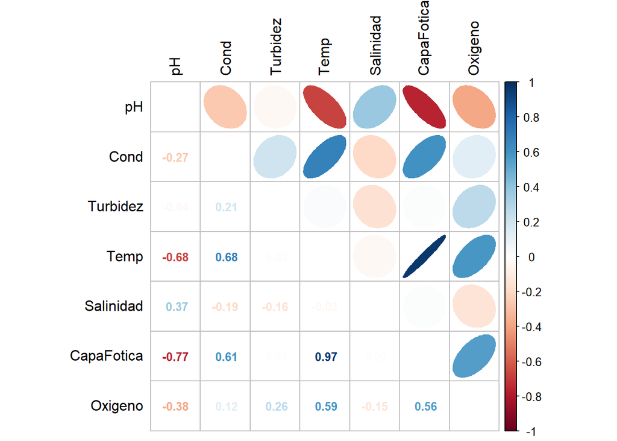

Figura 1: Correlaciones de Pearson entre las siete variables fisicoquímicas de las bahías.

```r
# Matriz de correlación con elipses y coeficientes
R_fq <- cor(fq)
corrplot.mixed(R_fq, upper = "ellipse", lower = "number",
               tl.col = "black", tl.pos = "lt", number.cex = 0.8)
```

La temperatura y la profundidad de la capa fótica tienen r = 0.97: casi la misma variable, como la salinidad y σt en el estudio de caso del Taller 7. Las dos se oponen al pH (r = -0.68 y -0.77). La turbidez y la salinidad casi no se relacionan con las demás.

### 2.2 Autovalores con tantas variables como bahías

**Código**

```r
# PCA de correlación de las siete variables
pca_fq <- prcomp(fq, scale. = TRUE)

autoval_fq <- tibble(Eje        = paste0("CP", 1:7),
                     Autovalor  = pca_fq$sdev^2,
                     Porcentaje = 100 * Autovalor / sum(Autovalor),
                     Acumulado  = cumsum(Porcentaje),
                     `Vara quebrada` = bstick(pca_fq))

autoval_fq %>%
  kbl(booktabs = TRUE, digits = c(0, 3, 1, 1, 2)) %>%
  kable_classic(full_width = F) %>%
  row_spec(0, bold = TRUE)
```

| Eje | Autovalor | Porcentaje | Acumulado | Vara quebrada |
| --- | --- | --- | --- | --- |
| CP1 | 3.406 | 48.7 | 48.7 | 2.59 |
| CP2 | 1.224 | 17.5 | 66.1 | 1.59 |
| CP3 | 0.984 | 14.1 | 80.2 | 1.09 |
| CP4 | 0.898 | 12.8 | 93.0 | 0.76 |
| CP5 | 0.463 | 6.6 | 99.6 | 0.51 |
| CP6 | 0.025 | 0.4 | 100.0 | 0.31 |
| CP7 | 0.000 | 0.0 | 100.0 | 0.14 |

El CP1 recoge el 48.7 % y el plano CP1–CP2 el 66.1 %. La vara quebrada retiene un eje (λ₁ = 3.41 > 2.59; λ₂ = 1.22 < 1.59). El CP7 tiene varianza cero: con 7 bahías solo caben 7 − 1 = 6 ejes (sección 1.5), y el CP6 (0.4 %) es casi solo temperatura (carga = -0.81): lo poco de ella que la capa fótica no repite.

**AdvertenciaDiseño (RA1): pocas muestras para tantas variables**

Con 7 bahías, cada correlación se estima con 7 pares de valores: una sola bahía puede cambiar el signo de una r moderada. El PCA describe estas siete bahías en estas fechas; no estima un patrón general de la costa. Para un PCA estable se recomienda tener bastantes más muestras que variables.

### 2.3 Qué dice cada eje

**Código**

```r
# Cargas y contribuciones de los dos primeros ejes
tibble(Variable  = rownames(pca_fq$rotation),
       Carga_CP1 = pca_fq$rotation[, 1], Carga_CP2 = pca_fq$rotation[, 2],
       Contr_CP1 = 100 * pca_fq$rotation[, 1]^2,
       Contr_CP2 = 100 * pca_fq$rotation[, 2]^2) %>%
  arrange(desc(Contr_CP1)) %>%
  kbl(booktabs = TRUE, digits = c(0, 2, 2, 1, 1),
      col.names = c("Variable", "Carga CP1", "Carga CP2",
                    "Contribución CP1 (%)", "Contribución CP2 (%)")) %>%
  kable_classic(full_width = F) %>%
  row_spec(0, bold = TRUE)
```

| Variable | Carga CP1 | Carga CP2 | Contribución CP1 (%) | Contribución CP2 (%) |
| --- | --- | --- | --- | --- |
| Temp | -0.52 | -0.21 | 27.0 | 4.3 |
| CapaFotica | -0.52 | -0.25 | 26.9 | 6.0 |
| pH | 0.43 | -0.06 | 18.3 | 0.3 |
| Cond | -0.36 | 0.04 | 13.0 | 0.1 |
| Oxigeno | -0.35 | 0.15 | 12.4 | 2.4 |
| Salinidad | 0.13 | -0.67 | 1.6 | 44.7 |
| Turbidez | -0.09 | 0.65 | 0.8 | 42.2 |

El CP1 opone el pH (0.43) a la temperatura (-0.52), la capa fótica (-0.52), la conductividad y el oxígeno. El CP2 es casi todo turbidez (0.65) frente a salinidad (-0.67): las dos variables que no se correlacionaban con las demás quedan solas en un eje.

### 2.4 Biplot y grupos del análisis de clúster

En el Taller 10, el análisis de clúster (distancia euclídea sobre las variables estandarizadas y método de Ward) separa las bahías en dos grupos. Se colorean en el biplot:

**Código**

```r
# Dos grupos de Ward sobre las variables estandarizadas (como en el Taller 10)
grp_fq <- factor(cutree(hclust(dist(scale(fq)), method = "ward.D2"), k = 2))
split(rownames(fq), grp_fq)
```

```
$`1`
[1] "Taganga"   "PtaBetin"  "Monohuaca"

$`2`
[1] "Granate"    "P.Grande"   "Rodadero"   "Aeropuerto"
```

**Código**

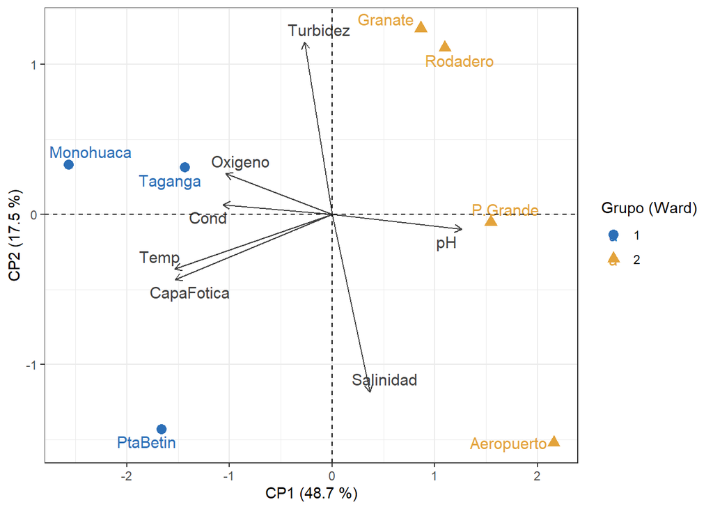

Figura 2: Biplot del PCA de correlación de las siete bahías, coloreadas por los dos grupos del análisis de clúster de Ward.

```r
# Biplot con los nombres de las bahías
fviz_pca_biplot(pca_fq, geom.ind = c("point", "text"), pointsize = 3,
                col.ind = grp_fq, palette = col_grp, labelsize = 4,
                mean.point = FALSE, col.var = "grey25", repel = TRUE,
                legend.title = "Grupo (Ward)", title = NULL) +
  labs(x = paste0("CP1 (", round(autoval_fq$Porcentaje[1], 1), " %)"),
       y = paste0("CP2 (", round(autoval_fq$Porcentaje[2], 1), " %)")) +
  theme_bw()
```

**Código**

```r
# Medias por grupo de las variables que construyen el CP1
fq %>%
  mutate(Grupo = grp_fq) %>%
  group_by(Grupo) %>%
  summarise(n = n(), across(c(pH, Temp, CapaFotica, Cond, Oxigeno), mean)) %>%
  kbl(booktabs = TRUE, digits = 2) %>%
  kable_classic(full_width = F) %>%
  row_spec(0, bold = TRUE)
```

| Grupo | n | pH | Temp | CapaFotica | Cond | Oxigeno |
| --- | --- | --- | --- | --- | --- | --- |
| 1 | 3 | 8.47 | 29.55 | 21.31 | 37.96 | 0.19 |
| 2 | 4 | 8.70 | 29.29 | 9.78 | 37.50 | 0.12 |

Los dos grupos se separan sobre el CP1: Taganga, Punta Betín y Monohuaca tienen la capa fótica más profunda y el agua algo más cálida; las otras cuatro bahías, un pH más alto y una capa fótica más somera. El clúster y el PCA cuentan la misma historia por dos caminos: el clúster **agrupa**, el PCA **muestra el gradiente** que explica los grupos.

**TipOrdenación y clasificación juntas**

Colorear una ordenación con los grupos de un clúster es una forma rápida de interpretar los grupos. Pero no es una prueba: los grupos se construyeron con las mismas variables, así que tienen que separarse en el PCA. Es el problema de circularidad que trata el Taller 10.

**Para discutir:** la temperatura y la capa fótica están casi perfectamente correlacionadas. Si se eliminara una de las dos, ¿cambiaría mucho el CP1? Pruébelo en el ejercicio 2.

## 3. PCA de Hellinger: macroinvertebrados del PNN Tayrona

**Pregunta:** ¿Se puede ordenar una matriz de abundancias con un PCA, y qué variables ambientales acompañan esa ordenación?

`Tayrona.csv` tiene la abundancia de 51 taxones de macroinvertebrados acuáticos y 11 variables fisicoquímicas en tres quebradas del Parque Nacional Natural Tayrona, muestreadas en época seca y de lluvias (Rodríguez-Barrios, 2023). Los nombres de fila combinan la quebrada y la época (`M.s` = quebrada M en seca).

**Código**

```r
# Lectura y factores (quebrada a partir del nombre de fila)
tay <- read.csv2(ruta_datos("Tayrona.csv"), row.names = 1) %>%
  mutate(Epoca    = factor(Epoca, levels = c("Seca", "Lluvia")),
         Quebrada = factor(sub("\\..*", "", rownames(.))))

# Matrices: ambiental (log10(x + 1) salvo el pH) y de taxones
X_tay <- tay %>% select(Alca:Temp) %>% mutate(across(-pH, ~ log10(.x + 1)))
Y_tay <- tay %>% select(Amb:Tric)

# Diseño: quebradas × épocas
table(tay$Quebrada, tay$Epoca)
```

```
     Seca Lluvia
  Bo    1      1
  M     1      1
  ST    1      1
```

**Código**

```r
c(muestras = nrow(Y_tay), taxones = ncol(Y_tay), ambientales = ncol(X_tay))
```

```
   muestras     taxones ambientales
          6          51          11
```

### 3.1 ¿Por qué no un PCA de las abundancias crudas?

Un PCA sobre conteos tiene dos problemas: los taxones más abundantes concentran la varianza, y la distancia euclídea trata los dobles ceros (dos sitios donde falta un taxón) como parecido. La transformación de Hellinger (Taller 5, Parte 5) convierte cada muestra en proporciones y saca la raíz; la distancia euclídea entre muestras transformadas es la distancia de Hellinger, adecuada para abundancias (Legendre y Gallagher, 2001).

**Código**

```r
# PCA de covarianza con conteos crudos y con Hellinger
pca_tay_crudo <- prcomp(Y_tay)
Y_tay_hel     <- decostand(Y_tay, method = "hellinger")
pca_tay       <- prcomp(Y_tay_hel)

# Tres taxones con mayor contribución al CP1 en cada caso
contr1 <- function(p) sort(100 * p$rotation[, 1]^2, decreasing = TRUE)[1:3]
list(crudos = round(contr1(pca_tay_crudo), 1), hellinger = round(contr1(pca_tay), 1))
```

```
$crudos
 Orth Chiro  Tric
 92.3   3.3   1.4

$hellinger
 Aty Orth Limo
46.0 11.4  5.1
```

**Código**

```r
# Abundancia total de los taxones más abundantes
sort(colSums(Y_tay), decreasing = TRUE)[1:3]
```

```
Orth Tric  Aty
1292  776  576
```

Con conteos crudos, Orth (el taxón más abundante, 1292 individuos) aporta el 92.3 % del CP1: el eje es ese taxón. Con Hellinger el peso se reparte, aunque Aty sigue aportando el 46.0 %: la transformación reduce la dominancia, no la elimina.

**ImportanteHellinger va con un PCA sin estandarizar**

Las abundancias transformadas ya están en la misma escala (proporciones), así que el PCA se calcula sobre la matriz de covarianza: `prcomp(Y_hel)`, sin `scale. = TRUE`. Estandarizar le daría a un taxón raro, presente en una sola muestra, el mismo peso que a uno común.

### 3.2 Autovalores con 6 muestras y 51 taxones

**Código**

```r
# Porcentaje de varianza por eje
round(100 * pca_tay$sdev^2 / sum(pca_tay$sdev^2), 1)
```

```
[1] 42.7 23.7 16.8 10.7  6.1  0.0
```

Hay 51 taxones, pero solo 6 muestras: el PCA tiene 5 ejes con varianza (6 − 1) y el último queda vacío. El plano CP1–CP2 recoge el 66.4 %.

### 3.3 Variables ambientales proyectadas con envfit

**Código**

```r
# Ajuste de las 11 ambientales sobre el plano CP1–CP2
set.seed(2026)
ef_tay <- envfit(pca_tay, X_tay, permutations = 999)

# Tabla con p ajustado (Holm) sobre las 11 variables
tab_tay <- tibble(Variable = names(ef_tay$vectors$r),
                  r2 = ef_tay$vectors$r,
                  p  = ef_tay$vectors$pvals) %>%
  mutate(p_Holm = p.adjust(p, method = "holm")) %>%
  arrange(p)

tab_tay %>%
  head(5) %>%
  kbl(booktabs = TRUE, digits = c(0, 2, 3, 2),
      col.names = c("Variable", "r²", "p", "p (Holm)")) %>%
  kable_classic(full_width = F) %>%
  row_spec(0, bold = TRUE)
```

| Variable | r² | p | p (Holm) |
| --- | --- | --- | --- |
| Sol | 0.90 | 0.033 | 0.37 |
| Alca | 0.78 | 0.092 | 0.92 |
| Nitri | 0.76 | 0.135 | 1.00 |
| Fosfa | 0.74 | 0.136 | 1.00 |
| Dure | 0.72 | 0.161 | 1.00 |

**Código**

```r
# Número de permutaciones que realmente se hicieron
ef_tay$vectors$permutations
```

```
[1] 719
```

Con 6 muestras solo existen 6! = 720 ordenamientos posibles, así que `envfit()` los recorre todos (719 permutaciones más el observado) aunque se pidan 999. Varias variables tienen r² altos (Sol: 0.90), pero con 6 puntos un r² alto es fácil de obtener por azar: 1 de las 11 tiene p < 0.05 sin corregir (Sol, p = 0.033), y con Holm (11 pruebas) ninguna se sostiene (menor p ajustado = 0.37).

**Código**

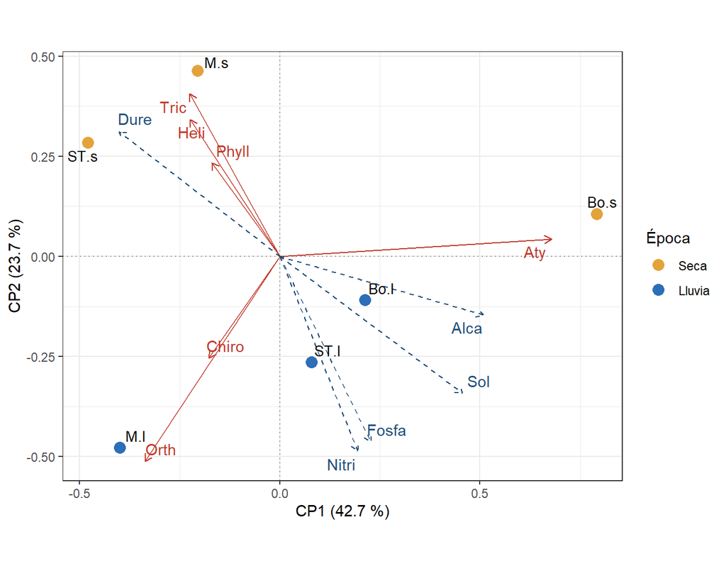

Figura 3: PCA de Hellinger de los macroinvertebrados del PNN Tayrona: muestras por época, los seis taxones con mayor contribución al plano (rojo) y las variables ambientales con r² > 0.7 en envfit (azul).

```r
# Coordenadas de las muestras
sc_tay <- as_tibble(pca_tay$x[, 1:2]) %>%
  mutate(Muestra = rownames(Y_tay), Epoca = tay$Epoca)

# Seis taxones con mayor contribución al plano CP1–CP2 (cargas reescaladas)
contr_plano <- rowSums(pca_tay$rotation[, 1:2]^2)
top_tax <- names(sort(contr_plano, decreasing = TRUE))[1:6]
fl_tax  <- as_tibble(pca_tay$rotation[top_tax, 1:2], rownames = "Taxon")

# Ambientales con r² > 0.7 (dirección de envfit, largo proporcional a √r²)
fl_amb <- as_tibble(scores(ef_tay, display = "vectors"), rownames = "Variable") %>%
  filter(ef_tay$vectors$r > 0.7) %>%
  mutate(across(c(PC1, PC2), ~ .x * 0.6))

ggplot() +
  geom_hline(yintercept = 0, linetype = 3, color = "grey60") +
  geom_vline(xintercept = 0, linetype = 3, color = "grey60") +
  geom_segment(data = fl_tax, aes(x = 0, y = 0, xend = PC1, yend = PC2),
               color = "#C0392B", arrow = arrow(length = unit(0.2, "cm"))) +
  geom_text_repel(data = fl_tax, aes(PC1, PC2, label = Taxon), color = "#C0392B") +
  geom_segment(data = fl_amb, aes(x = 0, y = 0, xend = PC1, yend = PC2),
               color = "#1F4E79", linetype = 2, arrow = arrow(length = unit(0.2, "cm"))) +
  geom_text_repel(data = fl_amb, aes(PC1, PC2, label = Variable), color = "#1F4E79") +
  geom_point(data = sc_tay, aes(PC1, PC2, color = Epoca), size = 3.5) +
  geom_text_repel(data = sc_tay, aes(PC1, PC2, label = Muestra), size = 3.5) +
  scale_color_manual(values = col_epoca, name = "Época") +
  coord_equal() +
  labs(x = paste0("CP1 (", round(100 * pca_tay$sdev[1]^2 / sum(pca_tay$sdev^2), 1), " %)"),
       y = paste0("CP2 (", round(100 * pca_tay$sdev[2]^2 / sum(pca_tay$sdev^2), 1), " %)")) +
  theme_bw()
```

**AdvertenciaDiseño (RA1): tres quebradas, dos épocas**

Las mismas tres quebradas se muestrearon en las dos épocas: las muestras forman **pares**, no seis réplicas independientes. Con tres pares, ninguna prueba de permutación que respete el diseño puede dar un p menor que 0.125 (sección 5). La figura sirve para describir y para plantear hipótesis, no para concluir que la época cambia la comunidad.

**NotaDel PCA de Hellinger a la RDA**

Proyectar las ambientales con `envfit()` es la versión exploratoria de una pregunta que la RDA (Taller 9) responde de forma directa: ¿cuánto de la composición explican las variables ambientales? Con 6 muestras y 11 variables, sin embargo, ni siquiera una RDA podría usarlas todas: tendría más variables que grados de libertad.

**Para discutir:** las muestras de una misma quebrada (`M.s` y `M.l`, por ejemplo), ¿quedan cerca en el plano? ¿Qué pesa más en esta comunidad: la quebrada o la época?

## 4. Biplot construido con ggplot2

**Pregunta:** ¿Cómo se construye, capa por capa, el biplot con elipses del Taller 7, y qué decide cada capa?

`fviz_pca_biplot()` resuelve la figura en una línea, pero decide por su cuenta el escalamiento, el largo de las flechas y el tipo de elipse. Con `ggplot2` cada decisión queda escrita. Se usan las coordenadas del **escalamiento 2** de `vegan` (Taller 7, Parte 4), en el que los ángulos entre flechas aproximan correlaciones.

**Código**

```r
# PCA de correlación con vegan y coordenadas en escalamiento 2
pca_v <- rda(X_log, scale = TRUE)

sc_m <- as_tibble(scores(pca_v, display = "sites", scaling = 2, choices = 1:2)) %>%
  mutate(Tributario = F_alg$Tributario, Cod = F_alg$Cod)
sc_v <- as_tibble(scores(pca_v, display = "species", scaling = 2, choices = 1:2),
                  rownames = "Variable")

# Porcentaje de varianza de los dos ejes para los rótulos
pct <- round(100 * eigenvals(pca_v)[1:2] / sum(eigenvals(pca_v)), 1)
```

### 4.1 Elipse de confianza de la media

`stat_ellipse()` de `ggplot2` dibuja elipses de **dispersión** (rodean a la mayoría de las muestras). La elipse del Taller 7 es de **confianza de la media**: la misma forma, pero con la covarianza dividida por n. Se construye con una función corta:

**Código**

```r
# Elipse de confianza (nivel 95 %) para el centroide de un grupo
elipse_media <- function(x, y, nivel = 0.95, npuntos = 100) {
  S   <- cov(cbind(x, y)) / length(x)                  # Covarianza de la media
  e   <- eigen(S)
  ang <- seq(0, 2 * pi, length.out = npuntos)
  circ <- rbind(cos(ang), sin(ang)) * sqrt(qchisq(nivel, df = 2))
  pts <- t(e$vectors %*% diag(sqrt(e$values)) %*% circ)
  tibble(x = mean(x) + pts[, 1], y = mean(y) + pts[, 2])
}

# Una elipse por tributario
elip <- sc_m %>%
  group_by(Tributario) %>%
  reframe(elipse_media(PC1, PC2))

# Centroides
cent <- sc_m %>%
  group_by(Tributario) %>%
  summarise(PC1 = mean(PC1), PC2 = mean(PC2))
```

### 4.2 La figura, capa por capa

**Código**

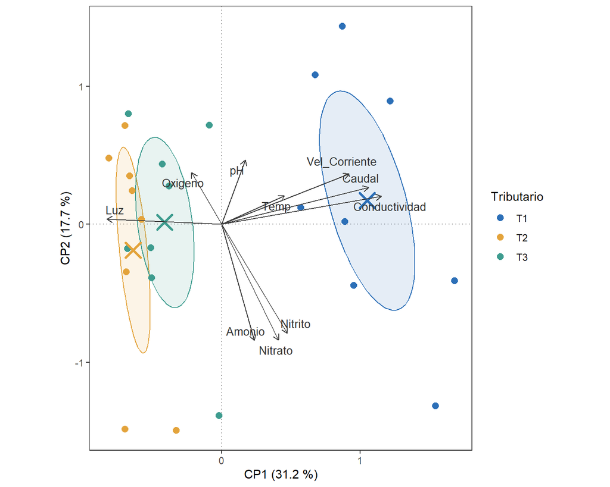

Figura 4: Biplot del PCA ambiental de microalgas en escalamiento 2, construido con ggplot2: muestras por tributario, elipses de confianza del 95 % para la media, centroides (cruces) y variables (flechas).

```r
ggplot() +
  # 1. Ejes de referencia
  geom_hline(yintercept = 0, linetype = 3, color = "grey60") +
  geom_vline(xintercept = 0, linetype = 3, color = "grey60") +
  # 2. Elipses de confianza de la media
  geom_polygon(data = elip, aes(x, y, fill = Tributario, color = Tributario),
               alpha = 0.12, show.legend = FALSE) +
  # 3. Muestras y centroides
  geom_point(data = sc_m, aes(PC1, PC2, color = Tributario), size = 2.5) +
  geom_point(data = cent, aes(PC1, PC2, color = Tributario),
             shape = 4, size = 5, stroke = 1.8, show.legend = FALSE) +
  # 4. Variables: flechas y rótulos sin superposición
  geom_segment(data = sc_v, aes(x = 0, y = 0, xend = PC1, yend = PC2),
               color = "grey25", arrow = arrow(length = unit(0.2, "cm"))) +
  geom_text_repel(data = sc_v, aes(PC1, PC2, label = Variable),
                  color = "grey20", size = 3.5) +
  # 5. Escalas, rótulos y tema
  scale_color_manual(values = col_trib) +
  scale_fill_manual(values = col_trib) +
  coord_equal() +
  labs(x = paste0("CP1 (", pct[1], " %)"), y = paste0("CP2 (", pct[2], " %)"),
       color = "Tributario") +
  theme_bw() +
  theme(panel.grid = element_blank())
```

| Capa | Decisión que queda escrita |
| --- | --- |
| `scores(..., scaling = 2)` | El escalamiento (se declara en el pie de figura) |
| `elipse_media()` | Elipse de la **media**, no de dispersión; nivel 95 % |
| Cruces (`shape = 4`) | Centroides calculados con las mismas coordenadas |
| `geom_text_repel()` | Rótulos que no se superponen |
| `coord_equal()` | Una unidad mide lo mismo en los dos ejes; sin ella, los ángulos se deforman |

**Nota¿Y la elipse de dispersión?**

Si la pregunta es dónde caen las muestras de cada tributario (y no dónde está su media), se cambia la capa 2 por `stat_ellipse(data = sc_m, aes(PC1, PC2, color = Tributario), type = "norm", level = 0.95)`. Con 8 visitas por tributario, la elipse de dispersión es casi tres veces (√8) más grande que la de confianza.

**Para discutir:** ¿por qué `coord_equal()` es indispensable en un biplot y no en una figura de barras?

## 5. envfit con permutaciones restringidas

**Pregunta:** ¿Cambia el p de `envfit()` si se respeta que las muestras no son intercambiables?

`envfit()` calcula el p permutando las filas: compara el r² observado con los r² obtenidos al reasignar al azar los valores del factor (o de la variable) entre las muestras. Por defecto, cualquier fila puede ir a cualquier posición (**permutación libre**). Eso supone que todas las muestras son intercambiables, y en los dos casos de este material no lo son.

### 5.1 Microalgas: el tributario dentro de cada visita

Las tres muestras de una misma visita se tomaron en la misma semana de colonización. Una permutación que respeta el diseño solo reasigna el tributario **dentro** de cada visita (bloque), con `how(blocks = …)` del paquete `permute` (que se carga con `vegan`):

**Código**

```r
# Diseño de permutación: libre dentro de cada visita
h_vis <- how(nperm = 999, blocks = F_alg$Visita)

# ¿Cuántas permutaciones distintas existen? (3! en cada una de 8 visitas)
numPerms(nrow(F_alg), h_vis)
```

```
[1] 1679616
```

**Código**

```r
# envfit del tributario con permutación libre y con bloques
set.seed(2026)
ef_libre <- envfit(pca ~ Tributario, data = F_alg, permutations = 999)
set.seed(2026)
ef_bloq  <- envfit(pca ~ Tributario, data = F_alg, permutations = h_vis)

tibble(Permutación = c("Libre", "Dentro de cada visita"),
       r2 = c(ef_libre$factors$r, ef_bloq$factors$r),
       p  = c(ef_libre$factors$pvals, ef_bloq$factors$pvals)) %>%
  kbl(booktabs = TRUE, digits = 3) %>%
  kable_classic(full_width = F) %>%
  row_spec(0, bold = TRUE)
```

| Permutación | r2 | p |
| --- | --- | --- |
| Libre | 0.58 | 0.001 |
| Dentro de cada visita | 0.58 | 0.001 |

El r² no cambia (0.58): la permutación solo afecta al p. Aquí el p se mantiene en 0.001 porque hay 1 679 616 permutaciones posibles dentro de las visitas y la separación de T1 es fuerte. Es el mismo diseño de permutación de la PERMANOVA de microalgas del Taller 10.

### 5.2 Tayrona: la época dentro de cada quebrada

**Código**

```r
# Diseño de permutación: la época se intercambia solo dentro de cada quebrada
h_queb <- how(nperm = 999, blocks = tay$Quebrada)

# Permutaciones posibles: 2 épocas en cada una de 3 quebradas
c(libre = numPerms(nrow(tay)), bloques = numPerms(nrow(tay), h_queb))
```

```
  libre bloques
    720       8
```

**Código**

```r
# envfit de la época con los dos diseños
set.seed(2026)
ef_ep_libre <- envfit(pca_tay ~ Epoca, data = tay, permutations = 999)
set.seed(2026)
ef_ep_bloq  <- envfit(pca_tay ~ Epoca, data = tay, permutations = h_queb)

tibble(Permutación = c("Libre", "Dentro de cada quebrada"),
       r2 = c(ef_ep_libre$factors$r, ef_ep_bloq$factors$r),
       p  = c(ef_ep_libre$factors$pvals, ef_ep_bloq$factors$pvals),
       `p mínimo posible` = 1 / c(numPerms(nrow(tay)), numPerms(nrow(tay), h_queb))) %>%
  kbl(booktabs = TRUE, digits = 3) %>%
  kable_classic(full_width = F) %>%
  row_spec(0, bold = TRUE)
```

| Permutación | r2 | p | p mínimo posible |
| --- | --- | --- | --- |
| Libre | 0.285 | 0.30 | 0.001 |
| Dentro de cada quebrada | 0.285 | 0.25 | 0.125 |

Con bloques por quebrada solo hay 2³ = 8 asignaciones posibles de la época (incluida la observada), así que el menor p alcanzable es 1/8 = 0.125. **Ningún resultado podría ser significativo al 5 %**, por fuerte que fuera el efecto. La permutación libre (720 ordenamientos) da una falsa sensación de potencia, porque mezcla las quebradas con la época.

**ImportanteRevisar `numPerms()` antes de interpretar un p**

Si el número de permutaciones posibles es pequeño, `vegan` las recorre todas aunque se pidan 999, y el p mínimo es 1 / (número de permutaciones). Con diseños pequeños, conviene calcularlo **antes** del muestreo: es una forma sencilla de saber si el diseño puede responder la pregunta (RA1).

**Para discutir:** ¿cuántas quebradas habría que muestrear en las dos épocas para que el p mínimo con bloques fuera menor que 0.05?

## 6. Guardado automático de figuras y tablas

**Pregunta:** ¿Cómo se obtienen las tablas del PCA y el biplot como archivos para la tesis o el artículo?

El bloque que guarda **todas** las figuras al renderizar (`knitr::opts_chunk$set(fig.path = ...)`) está en el material complementario del Taller 6. Aquí se guardan los productos del PCA de microalgas.

**Código**

```r
# Carpetas de salida
dir.create("outputs/fig", recursive = TRUE, showWarnings = FALSE)
dir.create("outputs/tab", recursive = TRUE, showWarnings = FALSE)

# Tablas del PCA: autovalores, cargas y coordenadas
tab_autoval <- tibble(Eje = paste0("CP", seq_along(pca$sdev)),
                      Autovalor = pca$sdev^2,
                      Porcentaje = 100 * pca$sdev^2 / sum(pca$sdev^2),
                      Acumulado = cumsum(Porcentaje))
tab_cargas  <- as_tibble(pca$rotation, rownames = "Variable")
tab_scores  <- bind_cols(F_alg, as_tibble(pca$x))

# Un libro de Excel con una hoja por tabla
write_xlsx(list(autovalores = tab_autoval, cargas = tab_cargas, coordenadas = tab_scores),
           path = "outputs/tab/pca_microalgas.xlsx")

# El biplot de la sección 4, guardado en un objeto y luego en archivo
p_biplot <- fviz_pca_biplot(pca, geom.ind = "point", col.ind = F_alg$Tributario,
                            palette = col_trib, addEllipses = TRUE,
                            ellipse.type = "confidence", mean.point = FALSE,
                            col.var = "grey25", repel = TRUE, title = NULL) +
  theme_bw()
ggsave("outputs/fig/biplot_microalgas.png", plot = p_biplot,
       width = 16, height = 12, units = "cm", dpi = 300)

# Archivos generados
list.files("outputs", recursive = TRUE)
```

```
[1] "fig/biplot_microalgas.png" "tab/pca_microalgas.xlsx"
```

**TipLas figuras de R base**

El gráfico de sedimentación con `screeplot()` o el biplot de `vegan` se dibujan con R base y no se guardan con `ggsave()`. Se abren un archivo con `png("outputs/fig/nombre.png", width = 16, height = 12, units = "cm", res = 300)`, se dibuja la figura y se cierra con `dev.off()`.

## 7. Ejercicios de práctica (sin nota)

Para practicar antes del estudio de caso:

1. Calcule con `eigen()` el PCA de las variables de bahías (`cor(fq)`) y compruebe que el CP7 tiene autovalor cero. ¿Qué pasaría con el CP7 si se agregara una octava bahía?
2. Repita el PCA de bahías sin la capa fótica. ¿Cambia el porcentaje del CP1? ¿Siguen separándose los dos grupos de Ward?
3. Haga el PCA de Tayrona con las abundancias en log10(x + 1) en lugar de Hellinger. ¿Qué taxón domina el CP1?
4. Haga un PCA de las 11 variables ambientales de Tayrona (`prcomp(X_tay, scale. = TRUE)`). ¿Cuántos ejes tienen varianza? ¿Por qué?
5. Cambie, en el biplot de la sección 4, la elipse de confianza por una de dispersión (`stat_ellipse()`). ¿Se siguen separando los tres tributarios?
6. Proyecte las 10 variables ambientales sobre el PCA de microalgas con `envfit()` y permutación dentro de cada visita, y compare los p con los de la permutación libre.

## Referencias

- Borcard, D., Gillet, F., & Legendre, P. (2018). *Numerical Ecology with R* (2nd ed.). Springer. https://doi.org/10.1007/978-3-319-71404-2
- Kassambara, A., & Mundt, F. (2020). *factoextra: Extract and Visualize the Results of Multivariate Data Analyses*. https://CRAN.R-project.org/package=factoextra
- Legendre, P., & Gallagher, E. D. (2001). Ecologically meaningful transformations for ordination of species data. *Oecologia*, 129(2), 271–280. https://doi.org/10.1007/s004420100716
- Legendre, P., & Legendre, L. (2012). *Numerical Ecology* (3rd ed.). Elsevier.
- Oksanen, J., Simpson, G. L., Blanchet, F. G., Kindt, R., Legendre, P., Minchin, P. R., et al. (2025). *vegan: Community Ecology Package*. https://CRAN.R-project.org/package=vegan
- Osorio Ávila, F. J., Rodríguez Barrios, J., & Montoya Moreno, Y. (2015). Sucesión de microalgas perifíticas en tributarios del río Gaira, Sierra Nevada de Santa Marta-Colombia. *Acta Biológica Colombiana*, 20(2), 119–131. https://doi.org/10.15446/abc.v20n2.41932 — Base de datos `Microalgas`.
- Rodríguez-Barrios, J. (2023). *Análisis de datos ecológicos y ambientales: aplicaciones con el programa R*. Díaz de Santos. — Bases de datos `FQmarino.csv` y `Tayrona.csv`.
- Simpson, G. L. (2022). *permute: Functions for Generating Restricted Permutations of Data*. https://CRAN.R-project.org/package=permute

**Nota**

Las figuras y el código de este material son de elaboración propia a partir de las bases citadas; no reproducen ejercicios ni código de las fuentes bibliográficas.